Pratibha Gautam

# Predicting Hospital Readmission using Machine Learning and Accessing Model Discrimination by Gender and Race

Hospitals often suffer from crowding and must allocate beds and resources to patients most in need [1]. A patient who is deemed to no longer require hospital care, can be discharged safely. However, hospitals often discharge patients who eventually are readmitted in a short time period. This might have negative consequences since we wrong in discharging them early.

In this project we attempt to predict whether a patient will be re-admitted to a hospital within a month. Such a model can be used to triage which patients should be discharged by their likelihood of re-admission. Moreover, we need to ensure and assess that this model performs equally well across different demographic groups. Previous work has shown that machine learning (ML) based algorithms are discriminatory in healthcare [2].

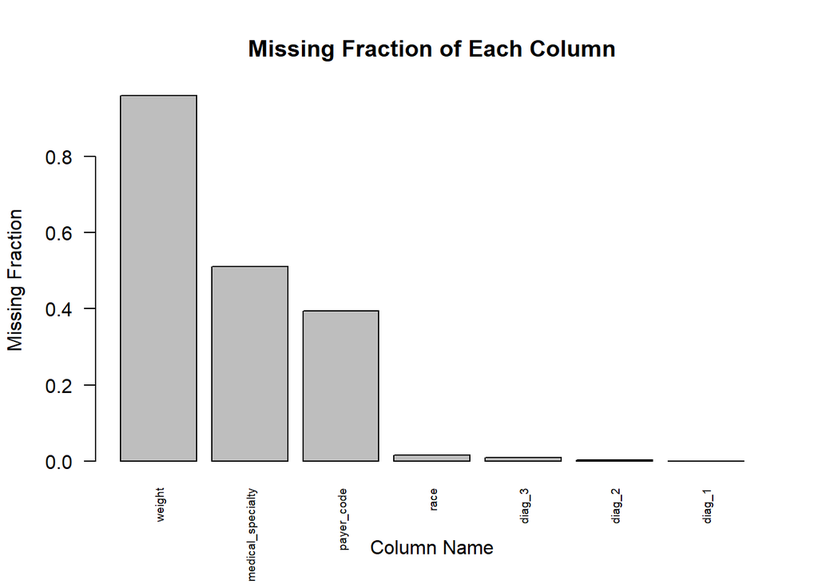

*Approach*: Approach: Our first step is to clean this dataset to make it ready for our machine learning models to learn on. We will impute missing values, recode values appropriately (numeric vs factor), remove columns that are uninformative and more. After that, we will split our dataset into 3 parts: training, validation and testing. We do this so that we can evaluate our model appropriately. After that, we learn different kinds of machine learning models on the training dataset and evaluate their performance with respect to the area under the receiving operating curve. We do this because the label distribution is uneven, in Figure 2 we show how many patients are readmitted within 30 days, notice that is it between 25%. Accuracy will not be as reliable measure of performance, especially since we want to rank patients for Triage. After picking the best model on the validation set, we measure it’s performance on the test. We then measure it’s performance by the subgroups of gender and race. We do this by computing confidence intervals for the AUC for each group and comparing them

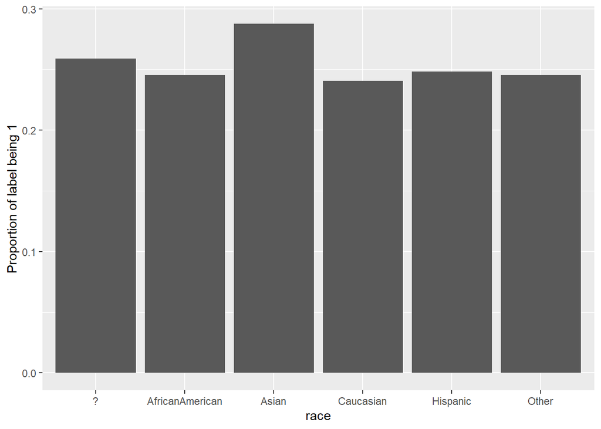

# Results

## Data Cleaning and Preparation

As we mentioned in the introduction, our dataset is messy and needs to be cleaned. We outline here all the steps we did to make our dataset ready for machine learning training and show our results.

*Step 1:* Removing rows with no labels. For more than 50% of points in our dataset, there is no record of re-admission of the patient, therefore we remove all these rows. We are left with 46902 patients. Note that we cannot impute the label as this would create bias in the dataset.

In addition to that, even numeric features in our dataset are coded as characters, thus we code everything appropriately to either numeric or factor appropriately. As a list filtering step, we look at correlations between features, however, we do not see any features that are redundant at the end of these 4 steps. Figure 3 shows this correlation between features.

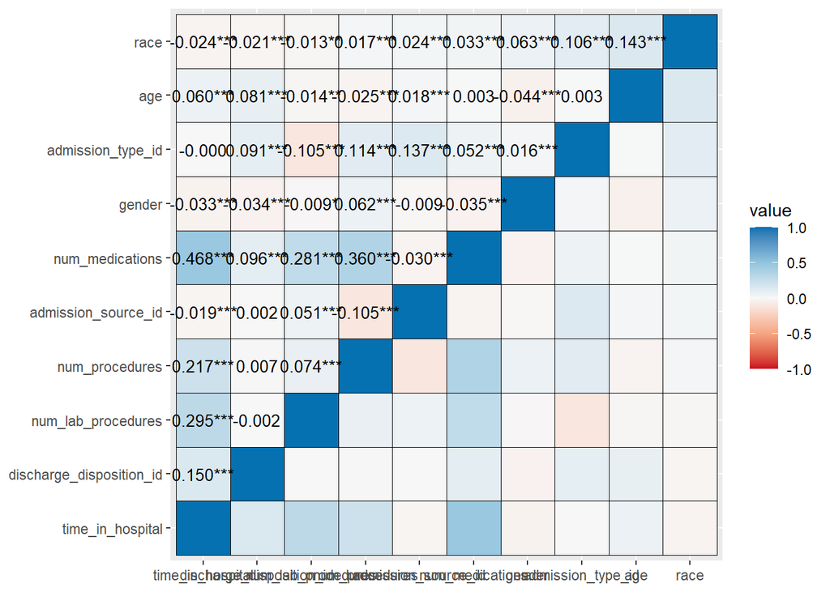

## Model Training

Using the split datasets from above, we are ready to train our machine learning models.

We experiment with a logistic regression baseline and a random forest model. We train both on our training data and evaluate their performance initially on our validation data. The results are in Table 1. We can see that the random forest model performs better than logistic regression baseline and has non-trivial performance. Thus we will use this random forest model going forward. Note we can improve performance by doing hyperparameter validation, but we leave this to future work.

| Model | Accuracy | AUC |
| --- | --- | --- |
| Logistic Regression | 0.758 | 0.593 |
| Random Forrest | 0.761 | 0.609 |

## Model Evaluation by Race and Gender

We are now ready to touch the test set and evaluate our model on it.

We obtain an AUC of 0.600 with a 90% confidence interval of [0.5873,0.6101] using the DeLong methods [4]. Before we evaluate the performance on the subgroups we are interested in, it is important to understand how many samples we have from each group. We plot the distribution of the population in each subgroup before data imputation in Figure 5. This will be very helpful in explaining our results in a second.

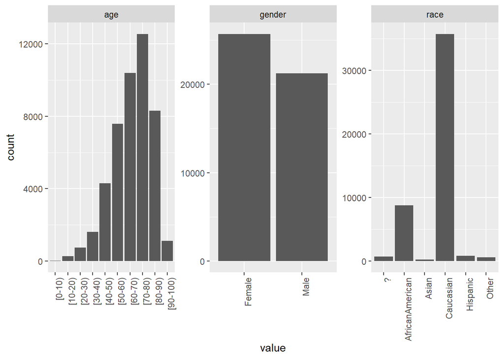

We plot in Figure 6, the AUC of the RF model on each of the subgroups. We first notice that the model performs slightly better on women than men. This can be partially explained because we have more data from women than we have for men (see Figure 5). In terms of race, we see that we have very large CI for all races except Caucasian and African American, this because of the limited data from these races. However, we notice that the performance on Caucasian is higher than that of African Americans. Another reason is that of unequal data from each group, since the model is trained to minimize average error, it will tend to do better on majority groups.

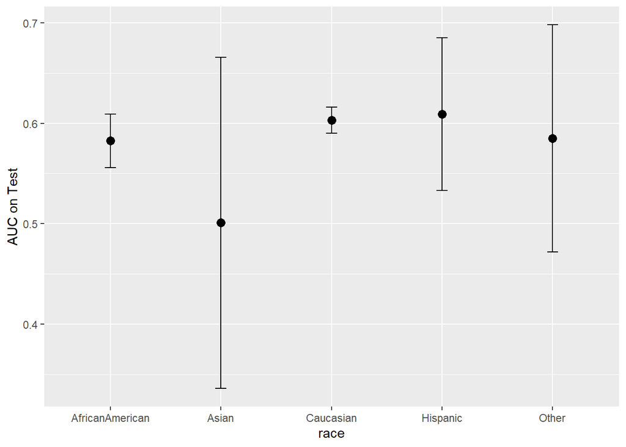

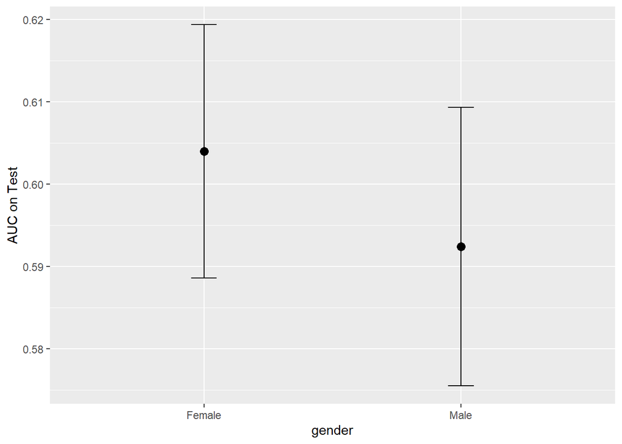

# Conclusion

In this project, we studied the problem of predicting diabetic patient readmission from hospital data. We first had to do significant data wrangling to make sure our dataset was clean and we are able to train models from it. We performed data imputation, feature selection and feature cleaning. We then learned different models including linear and random forest models to predict patient readmission. We used data splitting and AUC to evaluate our model performance since we had class imbalance. Our results showed that the random forest model performed best and had a non-trivial performance of 0.6 AUC. We then evaluated the performance of our model on the different subgroups in the dataset. Our results revealed a noticeable but not statistically significant gap between the model’s performance on women vs men and white vs African American. We explained that this gap might have occurred because of the unequal data sizes for each sub-group.

Future Work:

While our model’s performance was non-trivial, it is not as high as I would have hoped. I can improv the models performance by doing better hyperparameter tuning and training other types of models. One interesting direction if the rows with missing labels can still be leveraged to improv prediction using unsupervised learning.

While our work revealed some gap between the model performance on subgroups, we did not study how to address it in our work. One possible directions is to train models with explicit performance across different subgroups using fair machine learning and the fairml package [5].

# References

[1] McKenna P, Heslin SM, Viccellio P, Mallon WK, Hernandez C, Morley EJ. Emergency department and hospital crowding: causes, consequences, and cures. Clinical and experimental emergency medicine. 2019 Sep;6(3):189.

[2] Ledford H. Millions of black people affected by racial bias in health-care algorithms. Nature. 2019 Oct 1;574(7780):608-10.

[3] Strack B, DeShazo JP, Gennings C, Olmo JL, Ventura S, Cios KJ, Clore JN. Impact of HbA1c measurement on hospital readmission rates: analysis of 70,000 clinical database patient records. BioMed research international. 2014 Apr 3;2014.

[4] Demler OV, Pencina MJ, D’Agostino Sr RB. Misuse of DeLong test to compare AUCs for nested models. Statistics in medicine. 2012 Oct 15;31(23):2577-87.

[5] Package fairml [Internet]. CRAN. Comprehensive R Archive Network (CRAN); [cited 2022Dec18]. Available from: https://cran.r-project.org/web/packages/fairml/index.html

# Data Cleaning and Imputation

```r
library(tidyr)
library(dplyr)
library(caret)
library(randomForest)
library(xgboost)
library(caret)
library(e1071)
library(pROC)
```

```r
library(ggplot2)
library(pROC)
```

```r
data <- read.csv("dataset_diabetes/diabetic_data.csv")
```

```r
# first get rid of all points where we dont have information about re-admission
data = data[data$readmitted %in% c("<30", ">30"), ]
print(paste0("We have remaining points:", nrow(data)))
```

```
## [1] "We have remaining points:46902"
```

```r
data$readmitted = ifelse(data$readmitted == ">30", 0, 1)
table(data$readmitted)
```

```
##
##     0     1
## 35545 11357
```

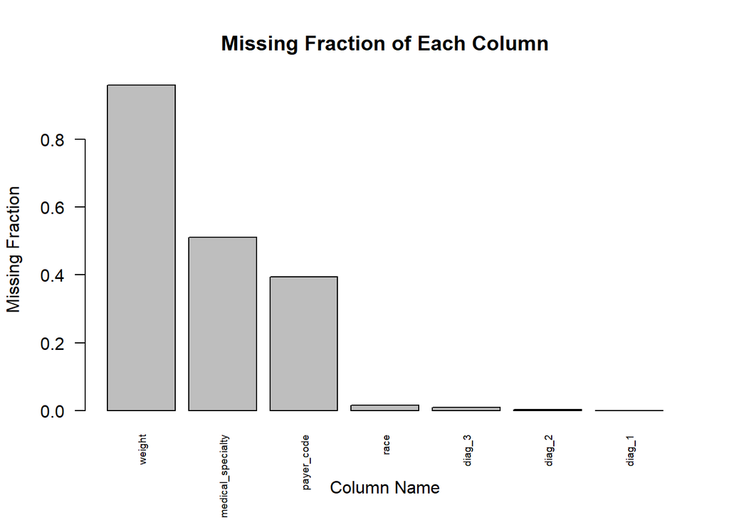

```r
missing_frac_col = rep(0,ncol(data))
for (i in 1:ncol(data)) {
  percent_missing = sum(data[[i]] == "?")/nrow(data)
  missing_frac_col[i] = percent_missing
}
missing_frac_col = data.frame(missing_frac_col)
colnames(missing_frac_col) = "missing_frac"
missing_frac_col = cbind(colnames(data),missing_frac_col)
missing_frac_col = missing_frac_col[order(missing_frac_col$missing_frac,decreasing = TRUE),]
missing_frac_col = missing_frac_col[missing_frac_col$missing_frac > 0,]
barplot(missing_frac_col$missing_frac,names.arg = missing_frac_col$colnames,las = 2,cex.names = 0.6,main = "Missing Fraction of Each Column",xlab = "Column Name",ylab = "Missing Fraction")
```

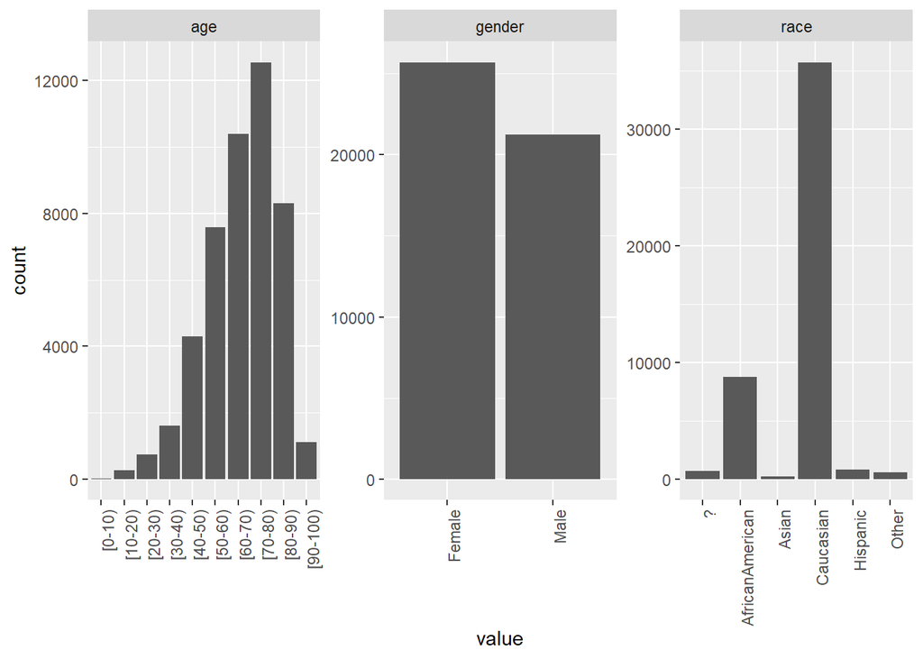

```r
data %>% gather()  %>% filter(key %in% c("age", "race","gender")) %>%  ggplot(aes(x = value)) + geom_bar() + facet_wrap(~key, scales = "free") + theme(axis.text.x = element_text(angle = 90, hjust = 1))
```

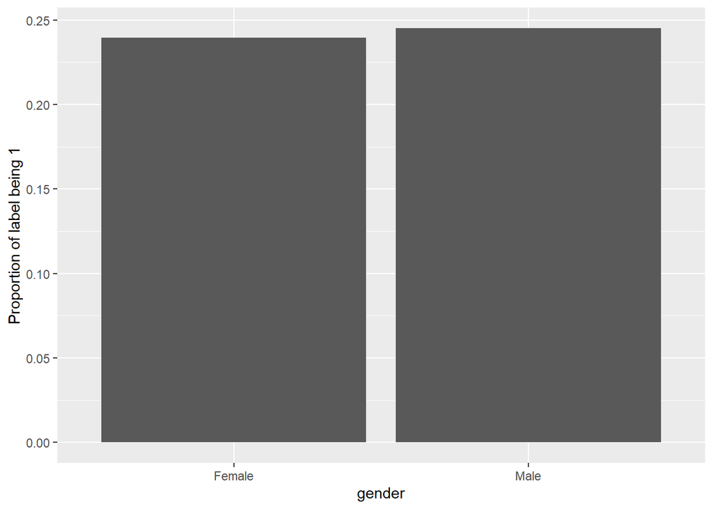

```r
plot_prop <- function(df, col, label){
  df %>%
    group_by(!!sym(col)) %>%
    summarise(prop = mean(!!sym(label))) %>%
    ggplot(aes(x = !!sym(col), y = prop)) +
    geom_bar(stat = "identity") +
    labs(x = col, y = "Proportion of label being 1")
}

plot_prop(data, "gender", "readmitted")
```

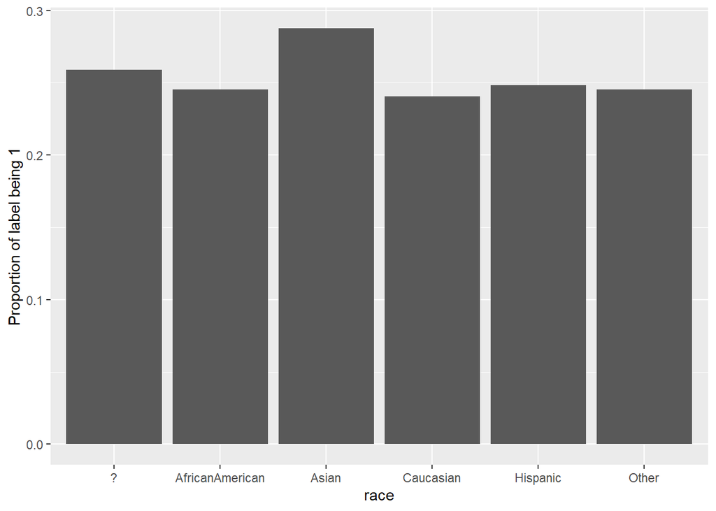

```r
plot_prop(data, "race", "readmitted")
```

```r
# remove columns with one unique values
data = data[, -which(names(data) == "examide")]
data = data[, -which(names(data) == "citoglipton")]

# we are going to remove columns that have more than 10% missigness
for (col in colnames(data)) {
  percent_missing = sum(data[[col]] == "?")/nrow(data)
  print(paste(col, sum(data[[col]] == "?")/nrow(data)))
  if (percent_missing >= 0.1){
        data = data[, !(names(data) %in% col)]
  }
}
```

```
## [1] "encounter_id 0"
## [1] "patient_nbr 0"
## [1] "race 0.0154790840475886"
## [1] "gender 0"
## [1] "age 0"
## [1] "weight 0.960193595155857"
## [1] "admission_type_id 0"
## [1] "discharge_disposition_id 0"
## [1] "admission_source_id 0"
## [1] "time_in_hospital 0"
## [1] "payer_code 0.393480022173894"
## [1] "medical_specialty 0.511641294614302"
## [1] "num_lab_procedures 0"
## [1] "num_procedures 0"
## [1] "num_medications 0"
```

[output cut: 33 more lines]

```r
# rest of columns we will impute with most common element
for (i in 1:ncol(data)) {
  if (any(data[, i] == "?")) {
    most_common = names(sort(table(data[, i]), decreasing = TRUE))[1]
    data[, i] = ifelse(data[, i] == "?", most_common, data[, i])
  }
}
# remove column "encounter_id"
data = data[, -1]
# remove column "patient_nbr"
data = data[, -1]
# remov diag_3, secondary diagnosis, too redundant
data = data[, -which(names(data) == "diag_3")]
```

```r
for (i in 1:ncol(data)) {
  print(paste(names(data)[i], length(unique(data[, i]))))
}
```

```
## [1] "race 5"
## [1] "gender 2"
## [1] "age 10"
## [1] "admission_type_id 7"
## [1] "discharge_disposition_id 23"
## [1] "admission_source_id 13"
## [1] "time_in_hospital 14"
## [1] "num_lab_procedures 111"
## [1] "num_procedures 7"
## [1] "num_medications 71"
## [1] "number_outpatient 39"
## [1] "number_emergency 31"
## [1] "number_inpatient 21"
## [1] "diag_1 613"
## [1] "diag_2 616"
```

[output cut: 27 more lines]

```r
data = data[, -which(names(data) == "metformin.rosiglitazone")]
data = data[, -which(names(data) == "metformin.pioglitazone")]


for (i in 1:ncol(data)) {
  if ((colnames(data)[i] %in% c("diag_1","diag_2","diag_3"))) {
    most_common = names(sort(table(data[, i]), decreasing = TRUE))[1:50]
    data[, i] = ifelse(data[, i] %in% most_common, data[, i], "other")
  }
}

for (i in 1:ncol(data)) {
  if (length(unique(data[, i])) > 7 & !(colnames(data)[i] %in% c("age","diag_1","diag_2","diag_3"))) {
    data[, i] = as.numeric(data[, i])
  } else {
    data[, i] = as.factor(data[, i])
  }
}
```

```
## Computing correlation using pearson-method with listwise-deletion...
```

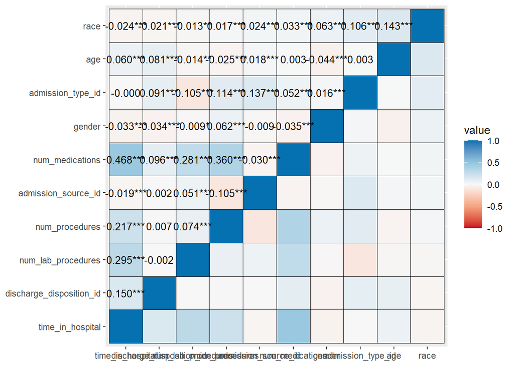

```r
data_copy = data[1:10]
data_copy[] <- lapply(data_copy,as.integer)
library(sjPlot)
sjp.corr(data_copy, wrap.labels =10, show.legend = TRUE)
```

# Learning Models

```r
# we will use sample splitting, and split into train, val and test 70:10:20
set.seed(2020)
trainIndex <- createDataPartition(y = data$readmitted, p = 0.7, list = FALSE)
train_data <- data[trainIndex, ]
test_data <- data[-trainIndex, ]
valIndex <- createDataPartition(y = test_data$readmitted, p = 0.333, list = FALSE)
val_data <- test_data[valIndex, ]
test_data <- test_data[-valIndex, ]
print(paste("train size:", nrow(train_data)))
```

```
## [1] "train size: 32832"
```

```r
print(paste("test size:", nrow(test_data)))
```

```
## [1] "test size: 9384"
```

```r
print(paste("val size:", nrow(val_data)))
```

```
## [1] "val size: 4686"
```

## Feature Selection

```r
#use roc_curve area as score
roc_imp <- filterVarImp(x = data[,1:39], y = data$readmitted)

#sort the score in decreasing order
roc_imp <- data.frame(cbind(variable = rownames(roc_imp), score = roc_imp[,1]))
roc_imp$score <- as.double(roc_imp$score)
roc_imp = roc_imp[order(roc_imp$score,decreasing = TRUE),]
roc_imp %>%
  select(variable, score) %>%
  knitr::kable()
```

|  | variable | score |
| --- | --- | --- |
| 5 | discharge_disposition_id | 0.5572135 |
| 13 | number_inpatient | 0.5479683 |
| 7 | time_in_hospital | 0.5295146 |
| 10 | num_medications | 0.5204923 |
| 9 | num_procedures | 0.5122071 |
| 6 | admission_source_id | 0.5108743 |
| 19 | metformin | 0.5096722 |
| 15 | diag_2 | 0.5095880 |
| 12 | number_emergency | 0.5090182 |
| 3 | age | 0.5087376 |
| 14 | diag_1 | 0.5061596 |
| 11 | number_outpatient | 0.5058282 |
| 16 | number_diagnoses | 0.5054868 |
| 8 | num_lab_procedures | 0.5051330 |
| 18 | A1Cresult | 0.5050416 |
| 28 | pioglitazone | 0.5049953 |
| 4 | admission_type_id | 0.5047899 |
| 29 | rosiglitazone | 0.5044204 |
| 25 | glipizide | 0.5039699 |
| 23 | glimepiride | 0.5037449 |
| 2 | gender | 0.5037072 |
| 39 | diabetesMed | 0.5027781 |
| 34 | insulin | 0.5020396 |
| 38 | change | 0.5017353 |
| 1 | race | 0.5016518 |
| 30 | acarbose | 0.5010071 |
| 26 | glyburide | 0.5008395 |
| 17 | max_glu_serum | 0.5007741 |
| 20 | repaglinide | 0.5002977 |
| 35 | glyburide.metformin | 0.5002830 |
| 22 | chlorpropamide | 0.5002582 |
| 31 | miglitol | 0.5001969 |
| 21 | nateglinide | 0.5001397 |
| 27 | tolbutamide | 0.5000544 |
| 36 | glipizide.metformin | 0.5000544 |
| 32 | troglitazone | 0.5000281 |
| 24 | acetohexamide | 0.5000141 |
| 37 | glimepiride.pioglitazone | 0.5000141 |
| 33 | tolazamide | 0.5000086 |

## Different Models

```r
linear <- glm(readmitted ~ ., data = train_data, family = 'binomial')
linear_pred <- predict(linear, newdata = val_data, type = "response")
linear_auc <- auc(val_data$readmitted, linear_pred)
linear_acc <- mean(val_data$readmitted == round(linear_pred))
print(linear_acc)
```

```
## [1] 0.7577892
```

```r
print(linear_auc)
```

```
## Area under the curve: 0.5933
```

```r
rf <- randomForest(readmitted ~ ., data = train_data, probability = TRUE)
rf_pred <- predict(rf, newdata = val_data,  type = "prob")[,2]
rf_auc <- auc(val_data$readmitted, rf_pred)
rf_acc <- mean(val_data$readmitted == round(rf_pred))
print(rf_auc)
```

```
## Area under the curve: 0.6091
```

```r
print(rf_acc)
```

```
## [1] 0.761417
```

RF is better, so we will use it as our final model

```r
rf_pred <- predict(rf, newdata = test_data,  type = "prob")[,2]
print(ci.auc(test_data$readmitted, rf_pred, conf.level = 0.9) )
```

```
## 90% CI: 0.5873-0.6101 (DeLong)
```

```r
print(mean(test_data$readmitted == round(rf_pred)))
```

```
## [1] 0.759058
```

Now let us evaluate the performance by group

```r
test_data$rf_pred = rf_pred
test_data$acc = (rf_pred == test_data$readmitted)
```

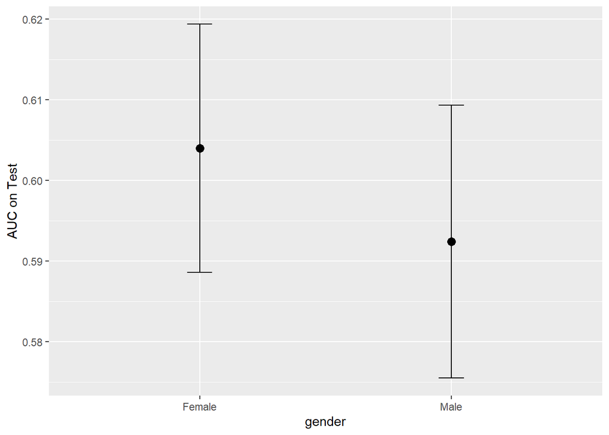

```r
plot_prop <- function(df, col){
  df %>%
    group_by(!!sym(col)) %>%
    summarise(prop = auc(readmitted, rf_pred)[1], conf_i1 = ci.auc(readmitted, rf_pred, conf.level = 0.9)[1], conf_i2 = ci.auc(readmitted, rf_pred, conf.level = 0.9)[3] ) %>%
    ggplot(aes(x = !!sym(col), y = prop)) +
    geom_errorbar(width=.1, aes(ymin=conf_i1, ymax=conf_i2)) +
    geom_point(shape=21, size=3, fill="black") +
    labs(x = col, y = "AUC on Test")
}

plot_prop(test_data, "gender")
```

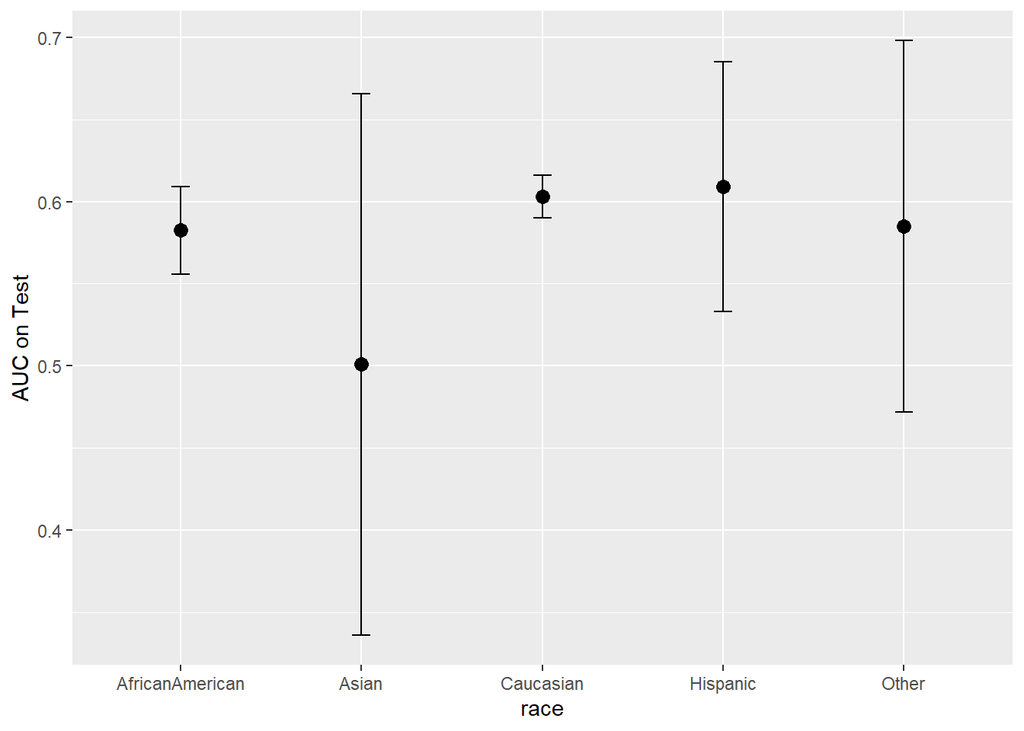

```r
plot_prop(test_data, "race")
```